# Dataset 1: /content/Final_Wales_Data.csv

```python
import pandas as pd
from sklearn.preprocessing import LabelEncoder, StandardScaler
from sklearn.model_selection import train_test_split
from sklearn.linear_model import LinearRegression
from sklearn.ensemble import RandomForestRegressor, GradientBoostingRegressor
from sklearn.svm import SVR
from sklearn.metrics import r2_score, mean_squared_error, mean_absolute_percentage_error
import numpy as np

# Load the DataFrame from the CSV file
final_combined_df = pd.read_csv('/content/Final_Wales_Data.csv')
final_combined_df.head(10)
final_combined_df2= final_combined_df
```

```python
final_combined_df.info()
```

```
<class 'pandas.core.frame.DataFrame'>
RangeIndex: 2808 entries, 0 to 2807
Data columns (total 9 columns):
 #   Column                         Non-Null Count  Dtype
---  ------                         --------------  -----
 0   Wales Regions                  2808 non-null   object
 1   Counties                       2808 non-null   object
 2   Number of Projects             2808 non-null   object
 3   Electrical Capacity (MWe)      2808 non-null   object
 4   Heat Capacity (MWth)           2808 non-null   object
 5   Electrical Generation (MWhe)   2808 non-null   object
 6   Heat Generation (MWhth)        2808 non-null   object
 7   Technology                     2808 non-null   object
 8   Year                           2808 non-null   int64
dtypes: int64(1), object(8)
memory usage: 197.6+ KB
```

```python
# List of columns that should be numeric
numeric_columns = ['Number of Projects ', 'Electrical Capacity (MWe) ',
                   'Heat Capacity (MWth) ', 'Electrical Generation (MWhe) ',
                   'Heat Generation (MWhth) ']

# Convert the columns to numeric, forcing errors to NaN (useful if there are any non-numeric values)
for col in numeric_columns:
    final_combined_df[col] = pd.to_numeric(final_combined_df[col].str.replace(',', '').str.strip(), errors='coerce')

# Check the data types after conversion
print(final_combined_df.dtypes)
```

```
Wales Regions                     object
Counties                          object
Number of Projects               float64
Electrical Capacity (MWe)        float64
Heat Capacity (MWth)             float64
Electrical Generation (MWhe)     float64
Heat Generation (MWhth)          float64
Technology                        object
Year                               int64
dtype: object
```

### Checking Overall values and estimating distribution of years In Dataset

```python
# Code to get unique values and their frequencies in the 'Year' column
year_counts = final_combined_df['Year'].value_counts()

# Sort by Year instead of frequency
year_counts_sorted = year_counts.sort_index()

# Print the sorted values and their frequencies
print(year_counts_sorted)
```

```
Year
2012    312
2014    312
2016    312
2017    312
2018    312
2019    312
2020    312
2021    312
2022    312
Name: count, dtype: int64
```

### Check for Missing Values in Dataset

```
Missing values in each column:
Wales Regions                     0
Counties                          0
Number of Projects               84
Electrical Capacity (MWe)        84
Heat Capacity (MWth)             84
Electrical Generation (MWhe)     84
Heat Generation (MWhth)          84
Technology                        0
Year                              0
dtype: int64
```

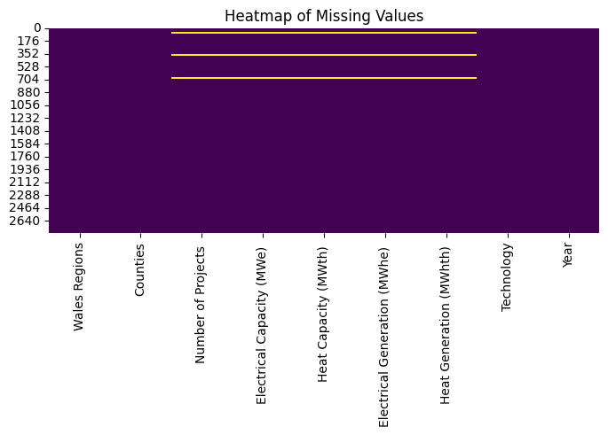

```python
import seaborn as sns
import matplotlib.pyplot as plt

# Check for missing values
missing_values = final_combined_df.isnull().sum()
print("Missing values in each column:")
print(missing_values)

# Plot heatmap to visualize missing values
plt.figure(figsize=(8, 3))
sns.heatmap(final_combined_df.isnull(), cbar=False, cmap='viridis')
plt.title("Heatmap of Missing Values")
plt.show()
```

### Filling Missing Values

If check the distribution of dataset the model is higher than mean or in another words there is saturation or peak recorded at 0, so, fill the missing values with 0 is best choice.

```python
final_combined_df2 = final_combined_df
final_combined_df.fillna(0, inplace=True)
final_combined_df2.fillna(0, inplace=True)
```

### Check for Duplicate values

```python
# Check for duplicate rows
duplicates = final_combined_df.duplicated().sum()
print(f"Number of duplicate rows: {duplicates}")
print("\n")
```

```
Number of duplicate rows: 0
```

### Check distribution of Each variables

Plotting Default distribution of each variable without any transformation or scaling in order to check overall distribution of data.

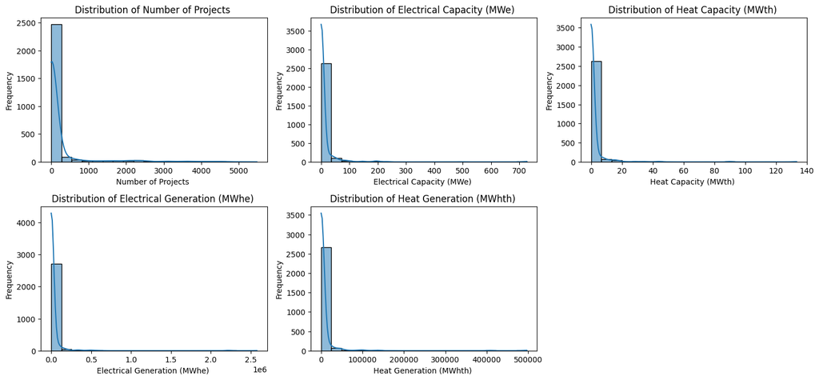

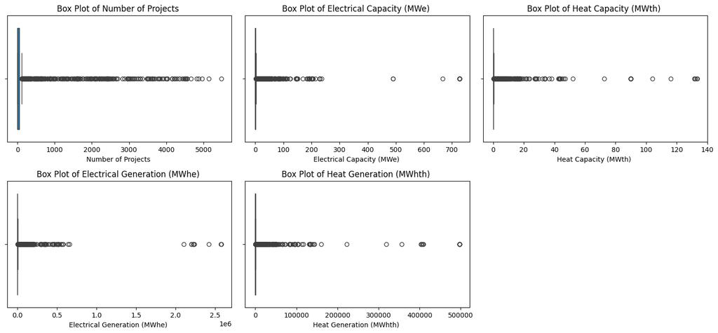

```python
import pandas as pd
import seaborn as sns
import matplotlib.pyplot as plt

numeric_columns = final_combined_df.select_dtypes(include=['float64']).columns

# Set up the matplotlib figure
plt.figure(figsize=(15, 10))

# Create a histogram for each numeric column
for i, column in enumerate(numeric_columns):
    plt.subplot(3, 3, i + 1)  # Adjust subplot dimensions as needed
    sns.histplot(final_combined_df[column], bins=20, kde=True)
    plt.title(f'Distribution of {column}')
    plt.xlabel(column)
    plt.ylabel('Frequency')

plt.tight_layout()
plt.show()

import pandas as pd
import seaborn as sns
import matplotlib.pyplot as plt

numeric_columns = final_combined_df.select_dtypes(include=['float64']).columns

# Set up the matplotlib figure
plt.figure(figsize=(15, 10))

# Create a box plot for each numeric column
for i, column in enumerate(numeric_columns):
    plt.subplot(3, 3, i + 1)  # Adjust subplot dimensions as needed
    sns.boxplot(x=final_combined_df[column])
    plt.title(f'Box Plot of {column}')
    plt.xlabel(column)

plt.tight_layout()
plt.show()
```

### Discussion:

1. From above charts this can be seen that the dataset is heavily Right Skewed, the maximum peak in dataset is recorded around **0** thats why there are many more outliers observed in data.
2. In order to deal with such charts there is need of transformation that can shift the data from right skewed to normal distribution.

## Transformation

### One major variant of the Box-Cox transformation, which is capable of dealing with positive- as well as negative-valued data, is the **Yeo-Johnson transformation**. Both of them are like Normalising, the idea of Yeo-Johnson transformation is to make the variance more consistent and bring the data closer to symmetry and resembling a normal distribution.

https://medium.com/@vinodkumargr/09-data-transformations-in-ml-different-transformations-in-machine-learning-log-transformer-d794d61d143d

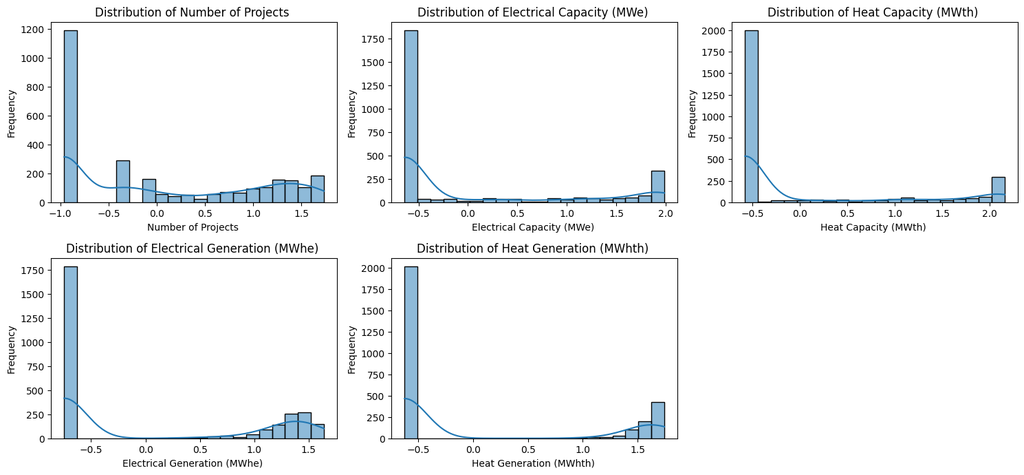

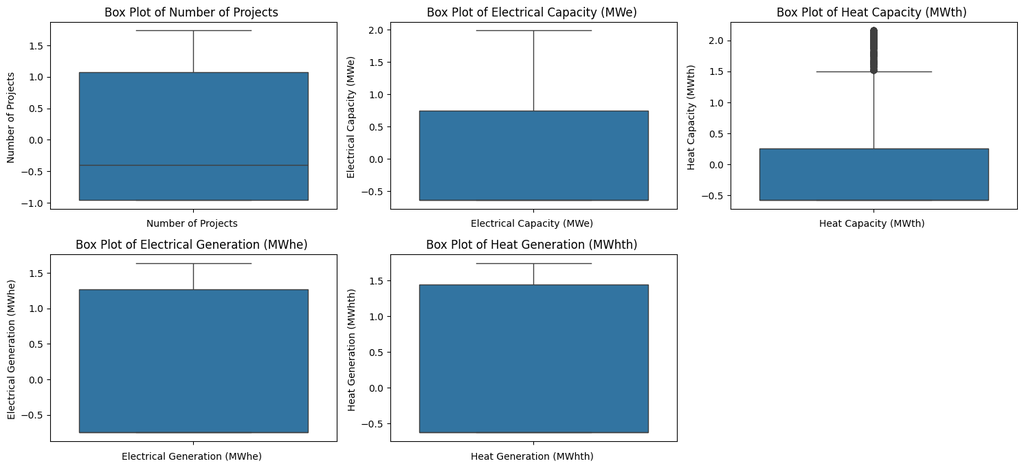

```python
from sklearn.preprocessing import PowerTransformer

# Apply Yeo-Johnson transformation
transformer = PowerTransformer(method='yeo-johnson', standardize=True)
final_combined_df[numeric_columns] = transformer.fit_transform(final_combined_df[numeric_columns])

# Set up the matplotlib figure
plt.figure(figsize=(15, 10))

# Create a histogram for each numeric column
for i, column in enumerate(numeric_columns):
    plt.subplot(3, 3, i + 1)  # Adjust subplot dimensions as needed
    sns.histplot(final_combined_df[column], bins=20, kde=True)
    plt.title(f'Distribution of {column}')
    plt.xlabel(column)
    plt.ylabel('Frequency')

plt.tight_layout()
plt.show()

numeric_columns = final_combined_df.select_dtypes(include=['float64']).columns

# Set up the matplotlib figure
plt.figure(figsize=(15, 10))

# Create a box plot for each numeric column
for i, column in enumerate(numeric_columns):
    plt.subplot(3, 3, i + 1)  # Adjust subplot dimensions as needed
    sns.boxplot(y=final_combined_df[column])
    plt.title(f'Box Plot of {column}')
    plt.xlabel(column)

plt.tight_layout()
plt.show()
```